# Biplots in 1D

[figure not shown]

This vignette illustrates how to create one-dimensional biplot. The biplotEZ vignette demonstrates many functions of the functions in the package. The vignette will serve as a supplement to the biplotEZ vignette.

# 1 One-dimensional PCA biplot

One-dimensional PCA biplots are obtained by specifying `dim.biplot = 1` in the call to `PCA()`.

The one-dimensional representation of the data is displayed by the colour points on the top horizontal line. The accompanying calibrated variable axes are displayed as horizontal lines below. The variable name is displayed on the side to which the variable increases.

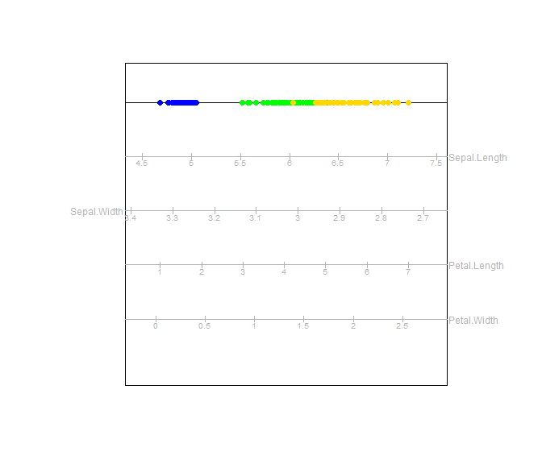

```r
biplot(iris) |> PCA(group.aes = iris$Species,dim.biplot = 1)  |> plot()
```

# 2 One-dimensional CVA biplot

Similarly for a CVA 1d biplot, `dim.biplot = 1` is specified in the call to `CVA()`. The one-dimensioal CVA biplot displays the one-dimensional linear combination that maximises the between class variance, relative to the within class variance.

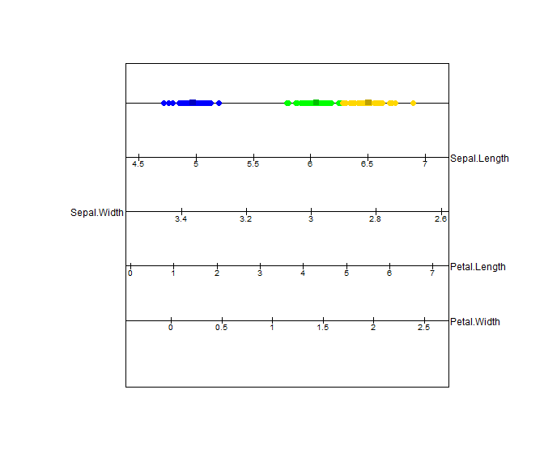

```r
biplot(iris) |> CVA(classes = iris$Species,dim.biplot = 1) |>
  axes(col="black") |> plot()
```

## 2.1 Classification using `classify()`

CVA models can be employed as a classifier. New observations are classified to the nearest class mean, where the means are indicated by the shaded squares on the scatter line. The classification regions are displayed above the scatter line using `classify()`.

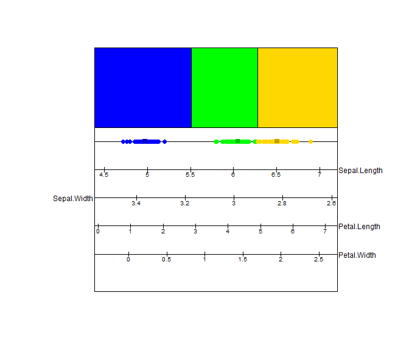

```r
bp <- biplot(iris) |> CVA(classes = iris[,5],dim.biplot = 1)|>
  axes(col="black") |>
  classify(borders = TRUE,opacity = 1)|>plot()
```

The `print()` function provides the misclassification rate, as well as the confusion matrix, of the CVA classifier applied to the training data.

```r
print(bp)
```

```
#> Object of class biplot, based on 150 samples and 5 variables.
#> 4 numeric variables.
#> 1 categorical variable.
#> 3 classes: setosa versicolor virginica
#>
#> Misclassification rate is  0.02
#>
#> Confusion matrix
#>             Reference
#> Prediction   setosa versicolor virginica
#>   setosa         50          0         0
#>   versicolor      0         48         2
#>   virginica       0          1        49
```

# 3 One-dimensional CA biplot

Similarly for a CA 1d biplot, `dim.biplot = 1` is specified in the call to `CA()`. The one-dimensional biplot is constructed from the first columns of $\mathbf{U\Lambda^\gamma}$ and $&\mathbf{V\Lambda^{1-\gamma}}$.

Consider the `HairEyeColor` example again as discussed in `CA in biplotEZ`:

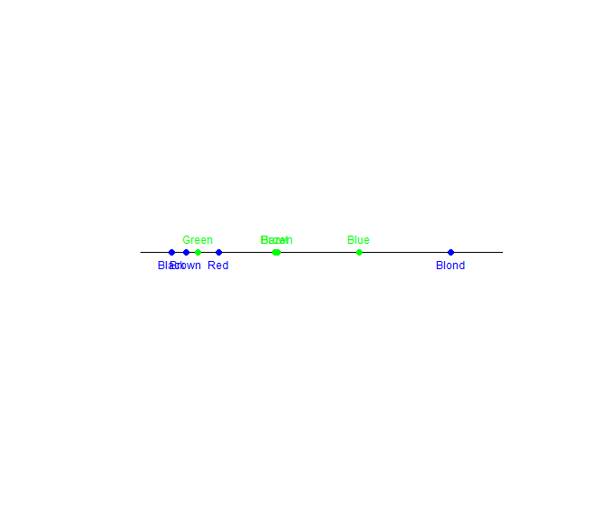

```r
biplot(HairEyeColor[,,2], center = FALSE) |> CA(variant = "Princ",
  dim.biplot=1, lambda.scal = T) |> plot()
```

# 4 The function `interpolate()`

`interpolate()` allows for new observations or axes to be added to the biplot.

## 4.1 The function `newsamples()`

The process of adding new samples to the biplot, called interpolation utilises the functions `interpolate()` and `newsamples()`. These functions work in the same way as in the call to the two-dimensional biplot. The function `interpolate()` accepts the argument `newdata` to specify a matrix or data frame containing the new samples to be interpolated. The function `newsamples()` operates the same way as `samples()` in that the user can specify the aesthetics of the interpolated samples.

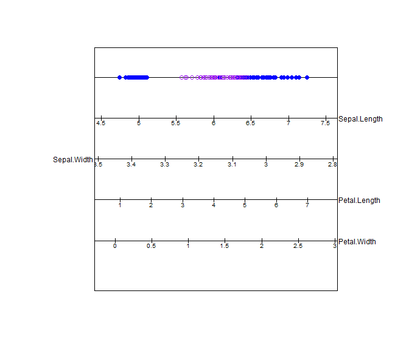

```r
biplot(iris[c(1:50,101:150),1:4])|> PCA(dim.biplot = 1) |> axes(col="black") |>
  interpolate(newdata = iris[51:100,1:4]) |> newsamples(col="purple") |> plot()
```

## 4.2 The function `newaxes()`

To interpolate new variables to the biplot, the function `interpolate()` and `newaxes()` are called. The function `interpolate()` accepts the argument `newvariable` to specify a matrix or data frame of the same number of rows in the data specified in `biplot()` containing the new variables to be interpolated. The function `newaxes()` allows the user to specify the aesthetics of the interpolated variables.

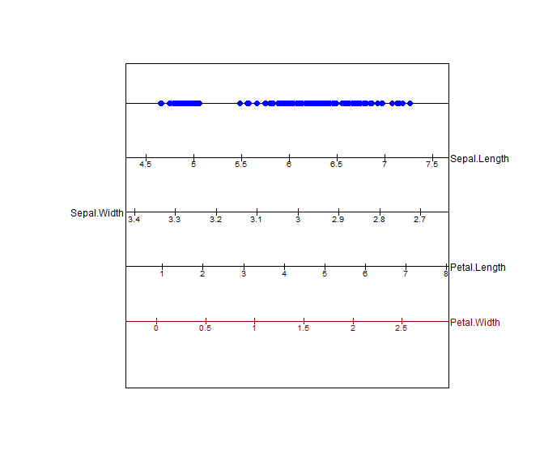

```r
biplot(iris[,1:3])|> PCA(dim.biplot = 1) |> axes(col="black") |>
  interpolate(newvariable = iris[,4]) |>
  newaxes(col="darkred",X.new.names = "Petal.Width") |> plot()
```

# 5 The function `prediction()`

## 5.1 Predicting Samples

To add the prediction of samples on the biplot, the `prediction()` function is used. The `predict.samples` argument takes in a vector indicating either the row numbers of the samples to predict or set to TRUE indicating to predict all samples. In the example below, the predictions for samples 100 to 150 are shown. The aesthetics for the display of the predictions are arguments in the `axes()` function: `predict.col` and `predict.lwd`.

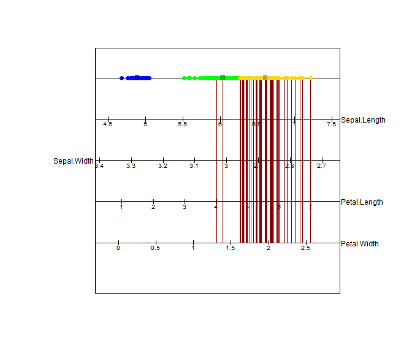

```r
biplot(iris) |>
  PCA(group.aes = iris$Species,dim.biplot = 1,show.class.means = TRUE) |>
  axes(col="black",predict.col = "darkred") |>
  prediction(predict.samples=100:150) |> plot()
```

## 5.2 Predicting Group Means

Similarly, to add the prediction of group means, the function `prediction()` is used. The argument `predict.means` takes in a vector specifying which group means to predict. In the example below, only the first group means is predicted. Important to note that the argument `show.class.means` must be set to TRUE in the `PCA()` function.

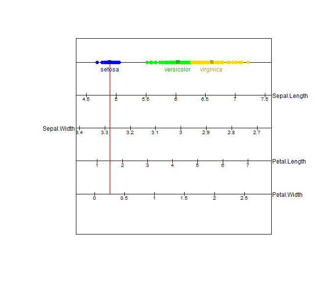

```r
biplot(iris) |>
  PCA(group.aes = iris$Species,dim.biplot = 1,show.class.means = TRUE) |>
  axes(col="black",predict.col = "darkred") |> means(label=TRUE,which=1:3)|>
  prediction(predict.means = 1) |> plot()
```

# 6 Ellipses and Alpha bags

Ellipses are added to a 1d biplot using the `ellipses()` function which works in the same way as a 2d biplot. In one dimension concentration ellipses are simply a confidence interval. The concentration interval is indicated using rectangles spanning the range of the interval.

```
#> Computing 1.96 -ellipse for setosa
#> Computing 1.96 -ellipse for versicolor
#> Computing 1.96 -ellipse for virginica
```

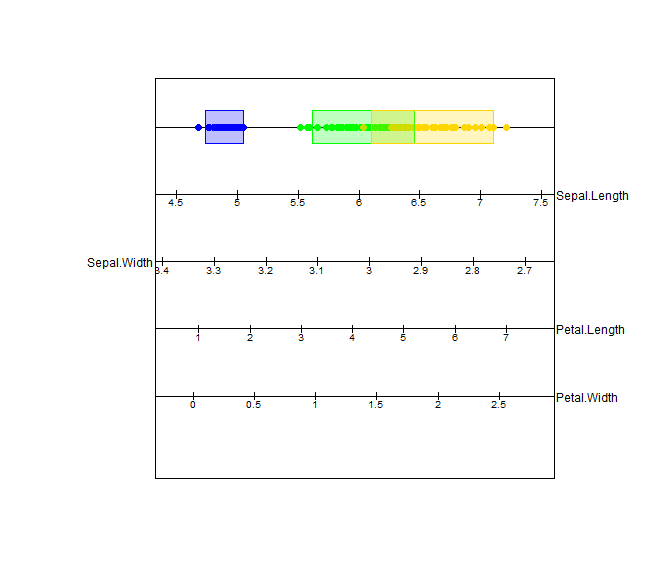

```r
biplot(iris) |> PCA(group.aes = iris[,5],dim.biplot = 1) |>
  axes(col="black") |>
  ellipses() |> plot()
```

The one-dimensional representation of an Alpha bag will simply be an empirical interval. The empirical interval is indicated using rectangles spanning the range of the interval.

```
#> Computing 0.7 -bag for setosa
#> Computing 0.7 -bag for versicolor
#> Computing 0.7 -bag for virginica
```

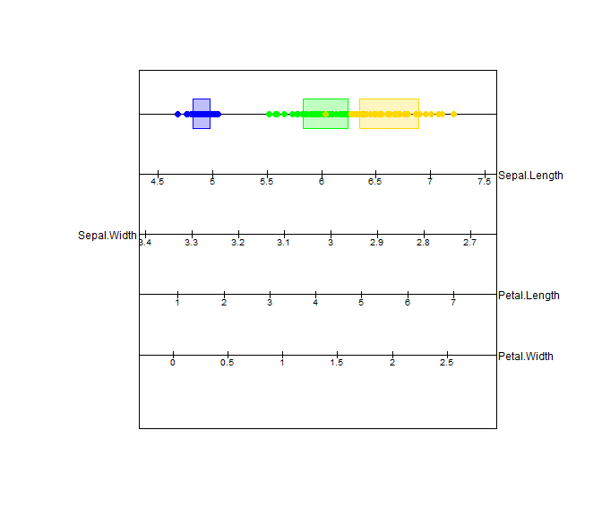

```r
biplot(iris) |> PCA(group.aes = iris[,5],dim.biplot = 1) |>
  axes(col="black") |>
  alpha.bags(alpha = 0.7) |> plot()
```

# 7 The function `density1D()`

Overlapping points make the distribution of points on the scatter line difficult to identify. `density1D()` uses kernel density estimation (KDE), which adds a density plot to the one-dimensional biplot.

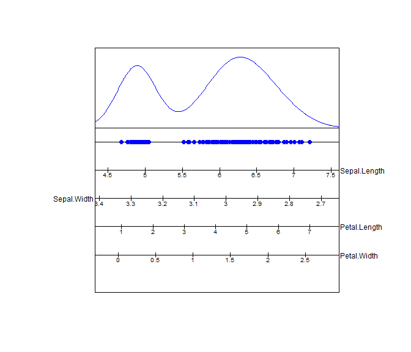

```r
biplot(iris) |> PCA(dim.biplot = 1) |>
  axes(col="black") |>
  density1D() |> plot()
```

This KDE may be too smooth to display the distribution of the data. By changing the parameters of the KDE, we are able to address this issue. The bandwidth and kernel used in `density1D()` are controlled by the arguments `h=` and `kernel=`, respectively. The bandwidth `h` can take any positive value, see `?stats::density` for more detail. `kernel` can take on any kernel supported by `stats::density()`.

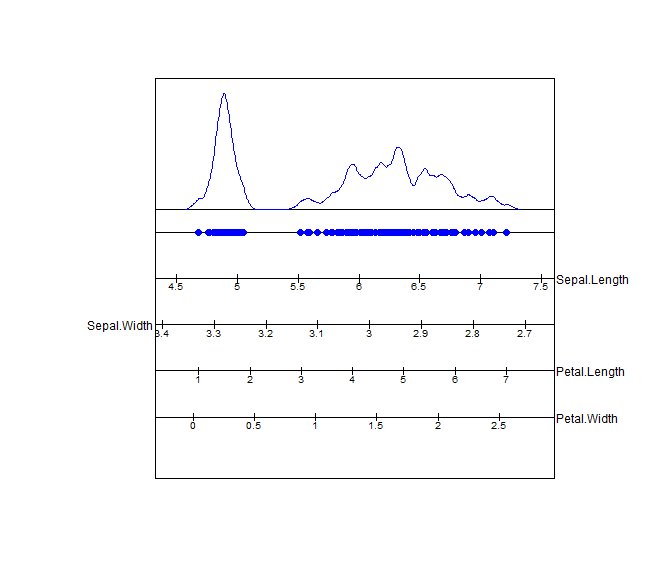

```r
biplot(iris) |> PCA(dim.biplot = 1) |> axes(col='black') |>
  density1D(h = 0.5 ,kernel = "triangular") |> plot()
```

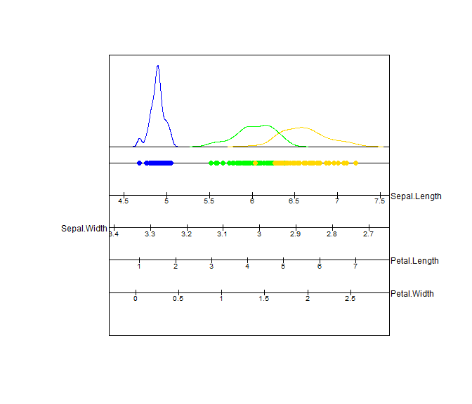

```r
biplot(iris) |> PCA(group.aes = iris[,5],dim.biplot = 1) |>
  axes(col="black") |>
  density1D() |> plot()
```

To only display the density of certain groups, use the `which=` argument in `density1D()`.

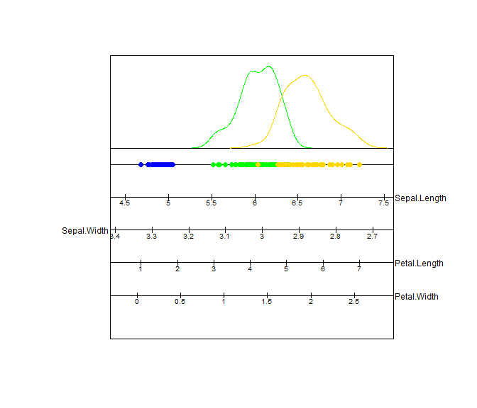

```r
biplot(iris) |> PCA(group.aes = iris[,5],dim.biplot = 1) |>
  axes(col="black") |>
  density1D(which = c(2,3)) |> plot()
```

# 8 The function `legend.type()`

`legend.type` adds a legend to the plot. A separate legend is created for each of the elements by setting each of `samples`, `means`, `bags` and `ellipses` equal to `TRUE`. Here, we add a legend for the samples.

```
#> Computing 0.95 -bag for setosa
#> Computing 0.95 -bag for versicolor
#> Computing 0.95 -bag for virginica
```

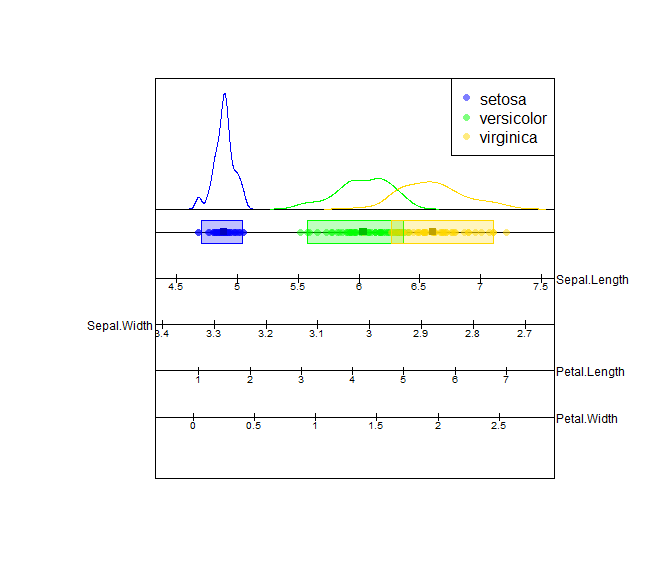

```r
biplot(iris) |> PCA(group.aes  = iris[,5],dim.biplot = 1, show.class.means = TRUE) |>
  axes(col="black") |> density1D() |> samples(opacity=0.5)|> alpha.bags()|>
  legend.type(samples = TRUE) |> plot()
```

If other legends are added, they will overlap with the elements of the plot as displayed below.

```
#> Computing 0.95 -bag for setosa
#> Computing 0.95 -bag for versicolor
#> Computing 0.95 -bag for virginica
```

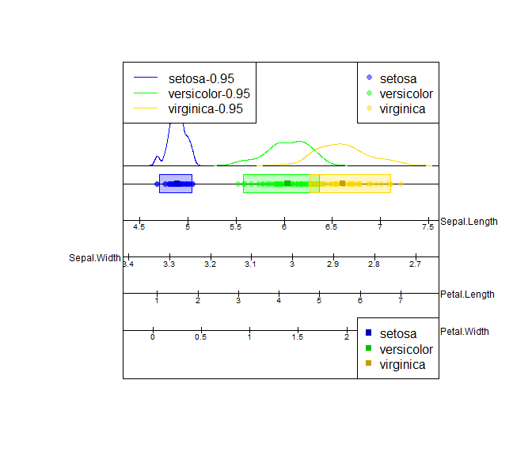

```r
biplot(iris) |> PCA(group.aes  = iris[,5],dim.biplot = 1, show.class.means = TRUE) |>
  axes(col="black") |> density1D() |> samples(opacity=0.5)|> alpha.bags()|>
  legend.type(samples = TRUE,means = TRUE, bags = TRUE) |> plot()
```

By specifying `new=TRUE`, the legends will be displayed on a new plot.

```
#> Computing 0.95 -bag for setosa
#> Computing 0.95 -bag for versicolor
#> Computing 0.95 -bag for virginica
```

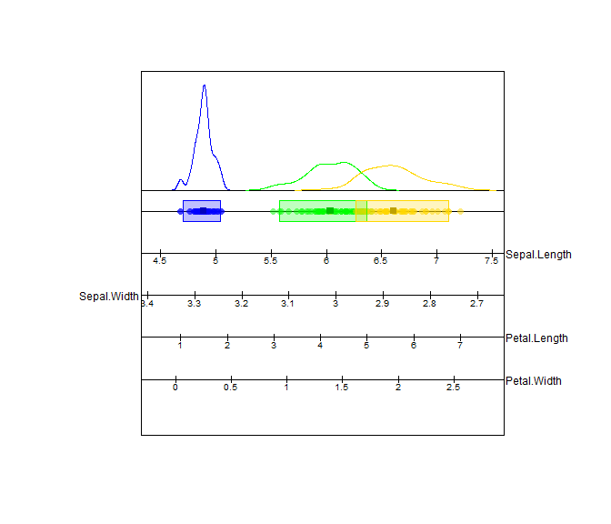

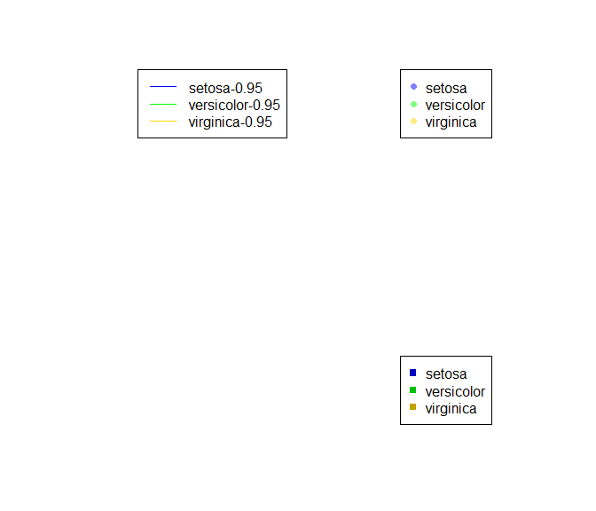

```r
biplot(iris) |> PCA(group.aes  = iris[,5],dim.biplot = 1, show.class.means = TRUE) |>
  axes(col="black") |> density1D() |> samples(opacity=0.5)|> alpha.bags()|>
  legend.type(samples = TRUE,means = TRUE, bags = TRUE, new=TRUE) |> plot()
```

```
#> Computing 0.95 -bag for setosa
#> Computing 0.95 -bag for versicolor
#> Computing 0.95 -bag for virginica
```

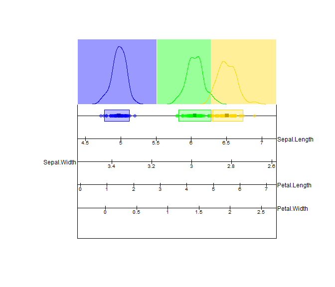

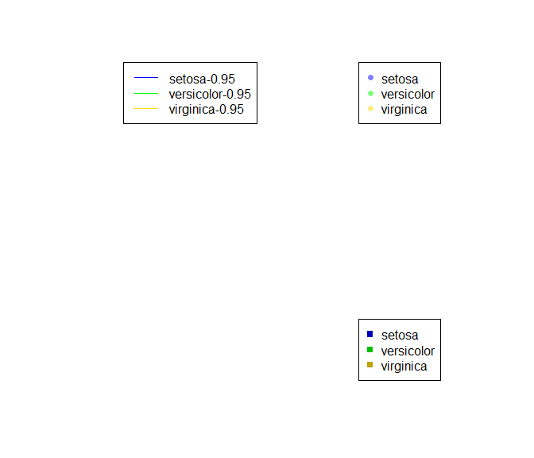

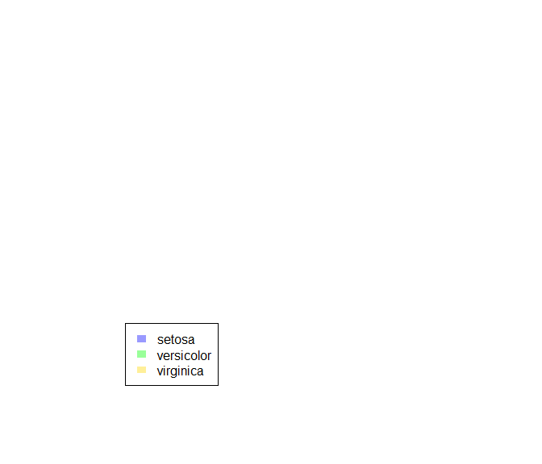

```r
bp <- biplot(iris) |> CVA(classes  = iris[,5],dim.biplot = 1, show.class.means = TRUE) |>
  axes(col="black") |> classify() |> density1D() |> samples(opacity=0.5)|> alpha.bags()|>
  legend.type(samples = TRUE,means = TRUE, bags = TRUE, regions = TRUE, new=TRUE) |> plot() #
```

# 9 The function `fit.measures()`

`fit.measures()` calculates measures of fit for the biplot. Passing a biplot object which has been piped to `fit.measures()` to `summary()` will output:

- For the plot: Quality of fit.
- For each variable: an Adequacy measure and a measure of Axis Predictivity.
- For each sample: Sample Predictivity

```r
a <- biplot(iris) |> PCA(group.aes = iris[,5],dim.biplot = 1) |> fit.measures()
summary(a)
```

```
#> Object of class biplot, based on 150 samples and 5 variables.
#> 4 numeric variables.
#> 1 categorical variable.
#>
#> Quality of fit in 1 dimension(s) = 92.5%
#> Adequacy of variables in 1 dimension(s):
#> Sepal.Length  Sepal.Width Petal.Length  Petal.Width
#>  0.130600269  0.007144055  0.733884527  0.128371149
#> Axis predictivity in 1 dimension(s):
#> Sepal.Length  Sepal.Width Petal.Length  Petal.Width
#>    0.8053299    0.1590003    0.9957524    0.9342141
#> Sample predictivity in 1 dimension(s):
#>            1            2            3            4            5            6
#> 0.9859320755 0.9885358364 0.9974032622 0.9858701194 0.9843168833 0.8999107868
#>            7            8            9           10           11           12
#> 0.9904348916 0.9957802734 0.9612785710 0.9923358788 0.9370769165 0.9948836825
#>           13           14           15           16           17           18
#> 0.9875168089 0.9750670327 0.8294906959 0.7529871550 0.9071569468 0.9853898465
#>           19           20           21           22           23           24
#> 0.8616422955 0.9552462766 0.9620201204 0.9652955093 0.9901078239 0.9937624785
#>           25           26           27           28           29           30
#> 0.9810460091 0.9863832711 0.9951903602 0.9788910031 0.9826539385 0.9920053991
#>           31           32           33           34           35           36
#> 0.9923858356 0.9597307230 0.8986110971 0.8460407992 0.9949139602 0.9929589514
#>           37           38           39           40           41           42
#> 0.9371265524 0.9862655235 0.9733166664 0.9912721172 0.9891383317 0.8797484869
#>           43           44           45           46           47           48
#> 0.9825513928 0.9769811411 0.9396840258 0.9875952309 0.9530258191 0.9923056267
#>           49           50           51           52           53           54
#> 0.9503079288 0.9971653130 0.7221680790 0.8953237687 0.8532596845 0.0442100903
#>           55           56           57           58           59           60
#> 0.9129953358 0.6359273436 0.9116787898 0.3571098355 0.8281788080 0.0001270475
#>           61           62           63           64           65           66
#> 0.1332510142 0.8958907297 0.0818459091 0.9526971985 0.2540681791 0.7246059875
#>           67           68           69           70           71           72
#> 0.6197552004 0.1947357248 0.5937494624 0.0051154548 0.8476044276 0.6378818290
#>           73           74           75           76           77           78
#> 0.8806268185 0.8333647070 0.8003003948 0.7880417411 0.8419077254 0.9590386463
#>           79           80           81           82           83           84
#> 0.9582463503 0.2779242770 0.0082643376 0.0606288071 0.1243095987 0.9010013410
#>           85           86           87           88           89           90
#> 0.4112193414 0.7631565205 0.8696344890 0.5516294004 0.3190741381 0.0556990781
#>           91           92           93           94           95           96
#> 0.2922625503 0.9696427131 0.1971557114 0.3235202228 0.3247632177 0.5026574343
#>           97           98           99          100          101          102
#> 0.5643559551 0.9057638532 0.5676221930 0.4180323047 0.9171464166 0.8271416340
#>          103          104          105          106          107          108
#> 0.9806829065 0.9748867821 0.9851812054 0.9634762352 0.1357241699 0.9588447969
#>          109          110          111          112          113          114
#> 0.9664650500 0.9136258044 0.9543465424 0.9836661306 0.9843680241 0.7205977672
#>          115          116          117          118          119          120
#> 0.7597174900 0.9253702336 0.9925388347 0.8904535431 0.9774035332 0.7072260541
#>          121          122          123          124          125          126
#> 0.9631634829 0.6942722608 0.9562507107 0.9637593562 0.9632124205 0.9427733678
#>          127          128          129          130          131          132
#> 0.9657601543 0.9613019987 0.9845972460 0.9236214690 0.9539031336 0.8415331923
#>          133          134          135          136          137          138
#> 0.9775228161 0.9628241776 0.8556597753 0.9327799099 0.8909511203 0.9790497984
#>          139          140          141          142          143          144
#> 0.9273791355 0.9602863486 0.9614110358 0.8945281971 0.8271416340 0.9753298287
#>          145          146          147          148          149          150
#> 0.9351760753 0.9383233979 0.9136490692 0.9866832123 0.8702674447 0.8913242393
```

# 10 References